# Simple Linear Regression - Practice

## Simple Linear Regression

Regression models (both linear and non-linear) are used for predicting a real value, like salary for example. If your independent variable is time, then you are forecasting future values, otherwise your model is predicting present but unknown values. Regression technique vary from Linear Regression to SVR and Random Forests Regression.

**Linear regression** is a *basic* and *commonly* used type of **predictive analysis**. The overall idea of regression is to examine two things:

- Does a set of **predictor variables** do a good job in predicting an **outcome** (dependent) variable?
- Which variables in particular are **significant predictors** of the outcome variable, and in what way they do **impact** the outcome variable?

These regression estimates are used to explain the **relationship between one dependent variable and one or more independent variables**. The simplest form of the regression equation with one dependent and one independent variable is defined by the formula :  
$y = \beta_0 + \beta_1x$

In this part, you will understand and learn how to implement the **Simple Linear Regression** models:

[figure not shown]

#### Importing the libraries

```python
# Importing the libraries
import numpy as np
import matplotlib.pyplot as plt
import pandas as pd
```

```python
# Importing th esklearn libraries to train and test and to perform linear regression.
from sklearn.model_selection import train_test_split
from sklearn.linear_model import LinearRegression
```

#### Importing the dataset

```python
# Importing the dataset
df = pd.read_csv('../Data/Salary_Data.csv')
```

```python
# See the data frame information.
df.info()
```

```
<class 'pandas.core.frame.DataFrame'>
RangeIndex: 30 entries, 0 to 29
Data columns (total 2 columns):
YearsExperience    30 non-null float64
Salary             30 non-null float64
dtypes: float64(2)
memory usage: 560.0 bytes
```

```python
# See the dataframe header information.
df.head()
```

|  | YearsExperience | Salary |
| --- | --- | --- |
| 0 | 1.1 | 39343.0 |
| 1 | 1.3 | 46205.0 |
| 2 | 1.5 | 37731.0 |
| 3 | 2.0 | 43525.0 |
| 4 | 2.2 | 39891.0 |

[figure not shown]

#### Preparing data for X and Y

```python
X = df.iloc[:, :-1].values
y = df.iloc[:, 1].values
```

#### Splitting X and y into training and test datasets

```python
# Splitting the dataset into the Training set and Test set
X_train, X_test, y_train, y_test = train_test_split(X, y, test_size = 1/3, random_state = 0)
```

#### Fitting Simple Linear Regression to the Training set

```python
# Fitting Simple Linear Regression to the Training set
linreg = LinearRegression()
linreg.fit(X_train, y_train)
```

```
LinearRegression(copy_X=True, fit_intercept=True, n_jobs=None,
         normalize=False)
```

#### Predicting the Test set results

```python
# Predicting the Test set results
y_pred = linreg.predict(X_test)

df_sample = pd.DataFrame({'experience': X_test.tolist(), 'test_salary': y_test, 'predict_salary': y_pred})
# print(X_test, y_test, y_test)

df_sample
```

|  | experience | test_salary | predict_salary |
| --- | --- | --- | --- |
| 0 | [1.5] | 37731.0 | 40835.105909 |
| 1 | [10.3] | 122391.0 | 123079.399408 |
| 2 | [4.1] | 57081.0 | 65134.556261 |
| 3 | [3.9] | 63218.0 | 63265.367772 |
| 4 | [9.5] | 116969.0 | 115602.645454 |
| 5 | [8.7] | 109431.0 | 108125.891499 |
| 6 | [9.6] | 112635.0 | 116537.239698 |
| 7 | [4.0] | 55794.0 | 64199.962017 |
| 8 | [5.3] | 83088.0 | 76349.687193 |
| 9 | [7.9] | 101302.0 | 100649.137545 |

#### Visualising the Training set results

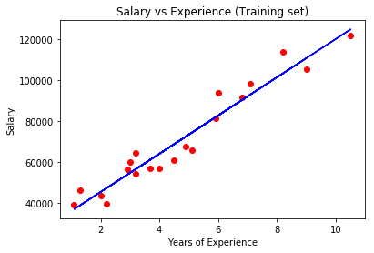

```python
# Visualising the Training set results
plt.scatter(X_train, y_train, color = 'red')
plt.plot(X_train, linreg.predict(X_train), color = 'blue')
plt.title('Salary vs Experience (Training set)')
plt.xlabel('Years of Experience')
plt.ylabel('Salary')
plt.show()
```

#### Visualising the Test set results

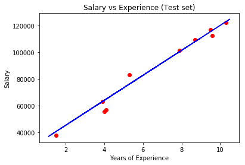

```python
# Visualising the Test set results
plt.scatter(X_test, y_test, color = 'red')
plt.plot(X_train, linreg.predict(X_train), color = 'blue')
plt.title('Salary vs Experience (Test set)')
plt.xlabel('Years of Experience')
plt.ylabel('Salary')
plt.show()
```